# draft_entrega

Joaquin Cerviño, Dario Ruiz, Esteban Lombera

30/09/2021

## Introducción y descripción de datos

El presente trabajo pretende analizar como varia el nivel de ruido ambiental en la Ciudad Autónoma de Buenos Aires (CABA) durante las fechas festivas (específicamente navidad, y año nuevo). Para ello, se realizaron medidas experimentales de ruido en 7 puntos (*n = 7*) de la CABA según su normativa vigente *([link](https://www.argentina.gob.ar/normativa/provincial/ley-1540-123456789-0abc-defg-045-1000xvorpyel))*. Por otro lado, se cuenta con medidas control de ruido en 7 puntos (*n = 7*) de la CABA provistas por la Agencia de Protección Ambiental (APrA) del Gobierno de la ciudad. Estas medidas control fueron obtenidas durante días de semana en periodos de actividad normal. La APrA cuanta con más de 400 puntos de medida distribuidos por toda la ciudad, Los 7 puntos control fueron seleccionados con el criterio de mayor proximidad a los puntos experimentales. La figura 1 muestra la distribución de los puntos de medida. En rojo los puntos experimentales y en azul los puntos control. Al hacer click en cada punto se puede visualizar su detalle.

```r
mapa.puntos = read.csv("./data/puntosEs.csv", header = TRUE, sep = ';', stringsAsFactors = TRUE)
lat = char2dms(as.character(mapa.puntos$Latitud), chd="°",chm="\'",chs="\"")
mapa.puntos$lat <- c(as.numeric(lat))
lng =  char2dms(as.character(mapa.puntos$Longitud), chd="°",chm="\'",chs="\"")
mapa.puntos$lng <- c(as.numeric(lng))
mapa.puntos %<>% mutate(
  lat = case_when(
    lat < 0 ~ lat,
    lat > 0 ~ lat * -1
  )
)
beatCol <- colorFactor(palette = c("blue","red"), mapa.puntos$Fecha)
labelPunto <- paste(sep=" ",'Punto', mapa.puntos$Posicion , mapa.puntos$Barrio...Comuna)
map <- leaflet() %>%
  addTiles() %>%
  addCircleMarkers(data = mapa.puntos, lat = ~lat, lng = ~lng,
                   color = ~beatCol(Fecha),
                   label = labelPunto)%>%
  addLegend("bottomright", pal = beatCol, values = mapa.puntos$Fecha,
            title = "Puntos de medida",
            opacity = .5)
map
```

[interactive chart not shown]

Cada sonómetro utilizado realizó mediciones de nivel de presión sonora en dBA cada 1 segundo a lo largo de 2 horas. Desde las 23:00hs hasta las 01:00hs. Las fechas de medición fueron iniciadas los días 24/12/2020 (Navidad) y 31/12/2020 (Año nuevo); y finalizadas los días 25/12/2020 y 1/1/2021 respectivamente. Los datos otorgados por la APrA corresponden a el Nivel Continuo Equivalente ponderado A medido entre las 23:00hs hasta las 01:00hs durante días no feriados de actividad normal (se descartan días durante vacaciones de invierno y verano). La tabla 1 muestra los datos obtenidos del nivel sonoro (dBA) por segundo para cada punto de medida en ambas fechas festivas. La tabla 2, presenta los datos provistos por la APrA del nivel continuo equivalente entre las 23:00 y las 01:00 para cada dia medido.

Tabla 1

```r
tabla.datos = read.csv("./data/datosR.csv", header = TRUE, sep = ';', stringsAsFactors = TRUE)
tabla.datos %<>% mutate(fecha = case_when(
  fecha != 'Navidad' ~ 'Año_nuevo',
  fecha == 'Navidad' ~ 'Navidad',
))
tabla.datos
```

| punto | tiempo | nivel_sonoro | fecha |
| --- | --- | --- | --- |
| P1 | 1 | 62.18 | Navidad |
| P1 | 2 | 62.38 | Navidad |
| P1 | 3 | 64.29 | Navidad |
| P1 | 4 | 62.76 | Navidad |
| P1 | 5 | 62.21 | Navidad |
| P1 | 6 | 63.51 | Navidad |
| P1 | 7 | 62.97 | Navidad |
| P1 | 8 | 64.29 | Navidad |
| P1 | 9 | 62.45 | Navidad |
| P1 | 10 | 62.99 | Navidad |

[output cut: 9990 more lines]

Tabla 2

```r
tabla.datosAPRA = read.csv("./data/datosAPrA.csv", header = TRUE, sep = ';', stringsAsFactors = TRUE)
tabla.datosAPRA
```

| punto | numero_dia | dia | LeqA |
| --- | --- | --- | --- |
| 1 | 3 | Miercoles | 67.3 |
| 1 | 4 | Jueves | 66.6 |
| 1 | 5 | Viernes | 67.7 |
| 1 | 6 | Sabado | 68.8 |
| 1 | 7 | Domingo | 66.0 |
| 1 | 1 | Lunes | 66.2 |
| 1 | 2 | Martes | 69.3 |
| 1 | 3 | Miercoles | 67.8 |
| 1 | 4 | Jueves | 66.6 |
| 1 | 5 | Viernes | 67.6 |

[output cut: 150 more lines]

La figura 2 muestra gráficamente los niveles de presión sonora en dBA a lo largo de los 7200 segundo (1 datos por segundo durante 2 horas) por cada punto de medida para las dos fechas (Navidad y Año nuevo)

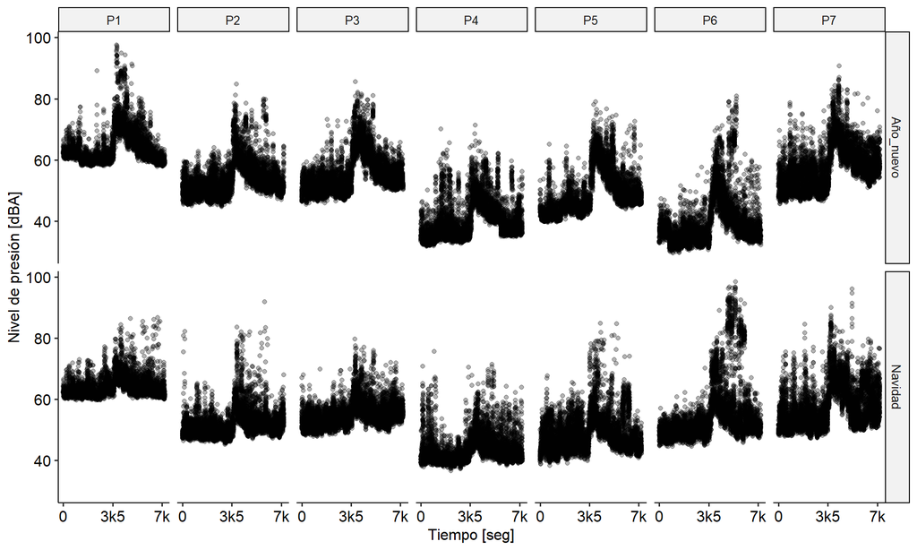

```r
figura1 = ggplot(tabla.datos, aes(x=tiempo, y=nivel_sonoro))+
          geom_point(alpha = 0.3)+
          facet_grid(fecha~punto)+
          theme_pubr(base_size = 12, margin = TRUE)+
          scale_x_continuous(name= "Tiempo [seg]", breaks=c(0,3500,7000), labels=c("0","3k5","7k")) +
          labs(y = "Nivel de presión [dBA]") +
          theme(legend.position = "top",
                legend.title = element_blank())
figura1
```

## Hipótesis de trabajo

Pretendemos analizar estos datos a fin de responder las siguientes hipótesis:

H1: El nivel de ruido ambiental en la CABA es significativamente mayor durante los festejos de navidad y año nuevo

H2: El nivel de ruido ambiental en la CABA durante los festejos de año nuevo es significativamente mayor que durante navidad

## Manipulación de datos

- Agregar a la tabla una fila que sea “condicion” que sea “con pirotecnia” cuando el tiempo es mayor a 3600 y “sin pirotecnia” cuando es menor o igual a 3600. Usar mutate —

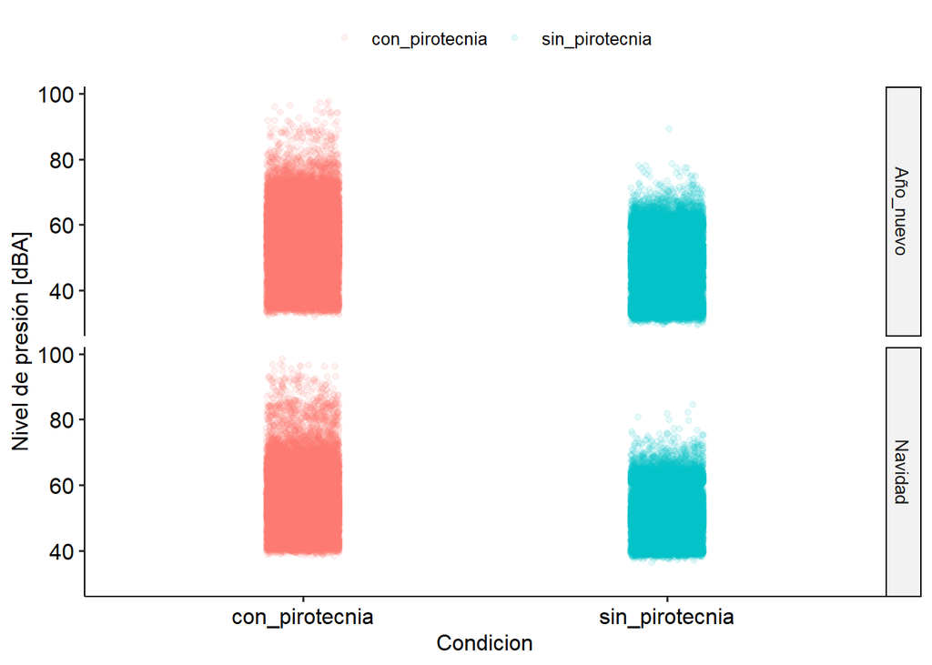

```r
tabla.datos <- tabla.datos %>%
  mutate(condicion = case_when(
    tiempo <= 3600 ~ 'sin_pirotecnia',
    tiempo > 3600 ~ 'con_pirotecnia',
  ))

tabla.datos.promedio <- tabla.datos %>%
  group_by(fecha,condicion) %>%
  summarise(nivel_sonoro_mean = mean(nivel_sonoro),
            nivel_sonoro_sd = sd(nivel_sonoro))
#tabla.datos.promedioMAL

fig = ggplot(tabla.datos, aes(x = condicion, y = nivel_sonoro, color = condicion))+
      geom_jitter(width = 0.1, alpha = 0.1)+
      # geom_boxplot()+
      facet_grid(fecha~.)+
      theme_pubr(base_size = 12, margin = TRUE)+
      labs(y = "Nivel de presión [dBA]", x = "Condicion") +
      theme(legend.position = "top",
            legend.title = element_blank())
fig
```

## Análisis estadistico

```r
modelo1 = lm(nivel_sonoro ~ fecha*condicion + punto,
             data = tabla.datos)

# nivel_sonoro = 55.15567 + 0.99329 "Navidad" -7.45520 "Sin pirotecnia" + 2.60660 "Navidad*Sin_pirotecnia
summary(modelo1)
```

```
##
## Call:
## lm(formula = nivel_sonoro ~ fecha * condicion + punto, data = tabla.datos)
##
## Residuals:
##     Min      1Q  Median      3Q     Max
## -17.402  -3.689  -0.671   2.724  47.935
##
## Coefficients:
##                                       Estimate Std. Error t value Pr(>|t|)
## (Intercept)                           66.52669    0.05943 1119.39   <2e-16 ***
## fechaNavidad                           0.99329    0.05316   18.68   <2e-16 ***
## condicionsin_pirotecnia               -7.45520    0.05316 -140.25   <2e-16 ***
## puntoP2                              -11.12658    0.07032 -158.23   <2e-16 ***
## puntoP3                               -8.61245    0.07032 -122.48   <2e-16 ***
## puntoP4                              -21.97888    0.07032 -312.56   <2e-16 ***
## puntoP5                              -14.87629    0.07032 -211.56   <2e-16 ***
## puntoP6                              -16.94503    0.07032 -240.98   <2e-16 ***
## puntoP7                               -6.05793    0.07032  -86.15   <2e-16 ***
## fechaNavidad:condicionsin_pirotecnia   2.60660    0.07517   34.67   <2e-16 ***
## ---
## Signif. codes:  0 '***' 0.001 '**' 0.01 '*' 0.05 '.' 0.1 ' ' 1
##
## Residual standard error: 5.966 on 100776 degrees of freedom
## Multiple R-squared:  0.6159, Adjusted R-squared:  0.6159
## F-statistic: 1.796e+04 on 9 and 100776 DF,  p-value: < 2.2e-16
```

```r
Anova(modelo1)
```

|  | Sum Sq | Df | F value | Pr(>F) |
| --- | --- | --- | --- | --- |
| fecha | 132915.61 | 1 | 3733.988 | 0.00000e+00 |
| condicion | 953584.17 | 1 | 26788.967 | 0.00000e+00 |
| punto | 4622934.37 | 6 | 21645.290 | 0.00000e+00 |
| fecha:condicion | 42798.38 | 1 | 1202.332 | 6.70351e-262 |
| Residuals | 3587237.91 | 100776 | NA | NA |

```r
modelo1 = lmer(nivel_sonoro ~ fecha*condicion + (1|punto),
             data = tabla.datos)

# nivel_sonoro = 55.15567 + 0.99329 "Navidad" -7.45520 "Sin pirotecnia" + 2.60660 "Navidad*Sin_pirotecnia
summary(modelo1)
```

```
## Linear mixed model fit by REML ['lmerMod']
## Formula: nivel_sonoro ~ fecha * condicion + (1 | punto)
##    Data: tabla.datos
##
## REML criterion at convergence: 646124.6
##
## Scaled residuals:
##     Min      1Q  Median      3Q     Max
## -2.9167 -0.6183 -0.1124  0.4565  8.0343
##
## Random effects:
##  Groups   Name        Variance Std.Dev.
##  punto    (Intercept) 53.51    7.315
##  Residual             35.60    5.966
## Number of obs: 100786, groups:  punto, 7
##
## Fixed effects:
##                                      Estimate Std. Error t value
## (Intercept)                          55.15567    2.76511   19.95
## fechaNavidad                          0.99329    0.05316   18.68
## condicionsin_pirotecnia              -7.45520    0.05316 -140.25
## fechaNavidad:condicionsin_pirotecnia  2.60660    0.07517   34.67
##
## Correlation of Fixed Effects:
##             (Intr) fchNvd cndcn_
## fechaNavidd -0.010
## cndcnsn_prt -0.010  0.500
## fchNvdd:cn_  0.007 -0.707 -0.707
```

```r
Anova(modelo1)
```

|  | Chisq | Df | Pr(>Chisq) |
| --- | --- | --- | --- |
| fecha | 3733.988 | 1 | 0.000000e+00 |
| condicion | 26788.967 | 1 | 0.000000e+00 |
| fecha:condicion | 1202.332 | 1 | 1.899109e-263 |

## Prueba de modelo de efectos mixtos

Esta es una prueba de creación de un modelo de efectos mixtos Voy a considerar fecha condicion y tiempo como efectos fijos y punto como efecto aleatorio.

```r
tabla.datos = read.csv("./data/datosR.csv", header = TRUE, sep = ';', stringsAsFactors = TRUE)

# tengo un problema de encoding con la ñ de columna Año Nuevo
tabla.datos %<>% mutate(fecha = case_when(
  fecha != 'Navidad' ~ 'Anio_nuevo',
  fecha == 'Navidad' ~ 'Navidad',
))

tabla.datos %<>%
  mutate(condicion = case_when(
    tiempo <= 3600 ~ 'sin_pirotecnia',
    tiempo > 3600 ~ 'con_pirotecnia',
  ))

pirotecnia.lme <- lme(nivel_sonoro ~ fecha*condicion*tiempo, data = tabla.datos, random = ~ 1|punto)

summary(pirotecnia.lme)
```

```
## Linear mixed-effects model fit by REML
##   Data: tabla.datos
##        AIC      BIC    logLik
##   625339.1 625434.3 -312659.6
##
## Random effects:
##  Formula: ~1 | punto
##         (Intercept) Residual
## StdDev:    7.315163 5.379194
##
## Fixed effects:  nivel_sonoro ~ fecha * condicion * tiempo
##                                                 Value Std.Error     DF
## (Intercept)                                  78.50683 2.7706845 100772
## fechaNavidad                                 -9.35391 0.2536808 100772
## condicionsin_pirotecnia                     -31.39714 0.1917599 100772
## tiempo                                       -0.00432 0.0000326 100772
## fechaNavidad:condicionsin_pirotecnia         13.03295 0.2711895 100772
## fechaNavidad:tiempo                           0.00192 0.0000461 100772
## condicionsin_pirotecnia:tiempo                0.00465 0.0000461 100772
## fechaNavidad:condicionsin_pirotecnia:tiempo  -0.00196 0.0000652 100772
##                                                t-value p-value
## (Intercept)                                   28.33482       0
## fechaNavidad                                 -36.87277       0
## condicionsin_pirotecnia                     -163.73149       0
## tiempo                                      -132.56493       0
## fechaNavidad:condicionsin_pirotecnia          48.05848       0
## fechaNavidad:tiempo                           41.53635       0
## condicionsin_pirotecnia:tiempo               100.87119       0
## fechaNavidad:condicionsin_pirotecnia:tiempo  -30.05073       0
##  Correlation:
##                                             (Intr) fchNvd cndcn_ tiempo fchN:_
## fechaNavidad                                -0.046
## condicionsin_pirotecnia                     -0.061  0.661
## tiempo                                      -0.064  0.694  0.919
## fechaNavidad:condicionsin_pirotecnia         0.043 -0.935 -0.707 -0.650
## fechaNavidad:tiempo                          0.045 -0.982 -0.650 -0.707  0.919
## condicionsin_pirotecnia:tiempo               0.045 -0.491 -0.866 -0.707  0.612
## fechaNavidad:condicionsin_pirotecnia:tiempo -0.032  0.695  0.612  0.500 -0.866
##                                             fchNv: cndc_:
## fechaNavidad
## condicionsin_pirotecnia
## tiempo
## fechaNavidad:condicionsin_pirotecnia
## fechaNavidad:tiempo
## condicionsin_pirotecnia:tiempo               0.500
## fechaNavidad:condicionsin_pirotecnia:tiempo -0.707 -0.707
##
## Standardized Within-Group Residuals:
##        Min         Q1        Med         Q3        Max
## -3.8430202 -0.5870728 -0.1091995  0.4494259  8.9183175
##
## Number of Observations: 100786
## Number of Groups: 7
```

El anova

```r
Anova(pirotecnia.lme)
```

|  | Chisq | Df | Pr(>Chisq) |
| --- | --- | --- | --- |
| fecha | 4593.4768 | 1 | 0.000000e+00 |
| condicion | 29579.0102 | 1 | 0.000000e+00 |
| tiempo | 8795.0632 | 1 | 0.000000e+00 |
| fecha:condicion | 1942.6873 | 1 | 0.000000e+00 |
| fecha:tiempo | 823.1310 | 1 | 5.047150e-181 |
| condicion:tiempo | 12679.3643 | 1 | 0.000000e+00 |
| fecha:condicion:tiempo | 903.0462 | 1 | 2.136021e-198 |

Y los residuos

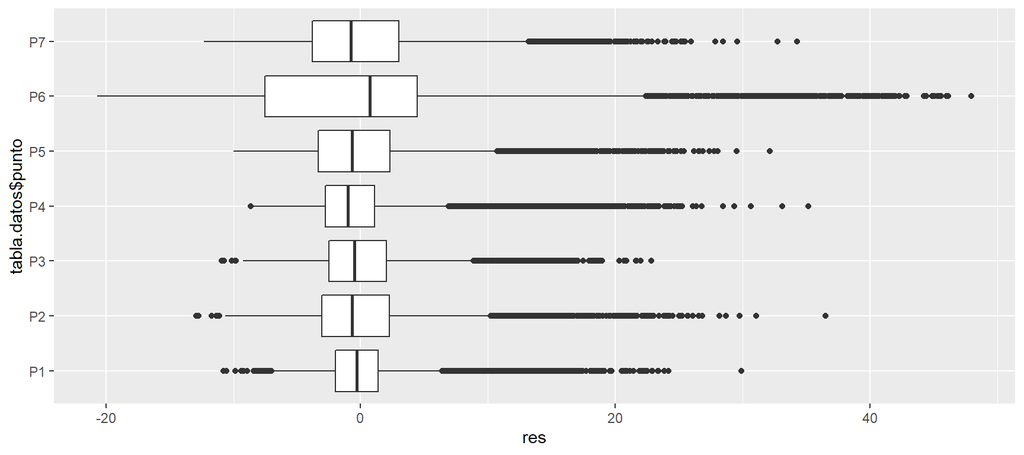

```r
residuo_datos2 <- tabla.datos %>% mutate(res = resid(pirotecnia.lme )) %>% tibble()
p3 = ggplot(residuo_datos2, aes(x = res, y = tabla.datos$punto)) + geom_boxplot()
p3
```

El modelo junto con los datos

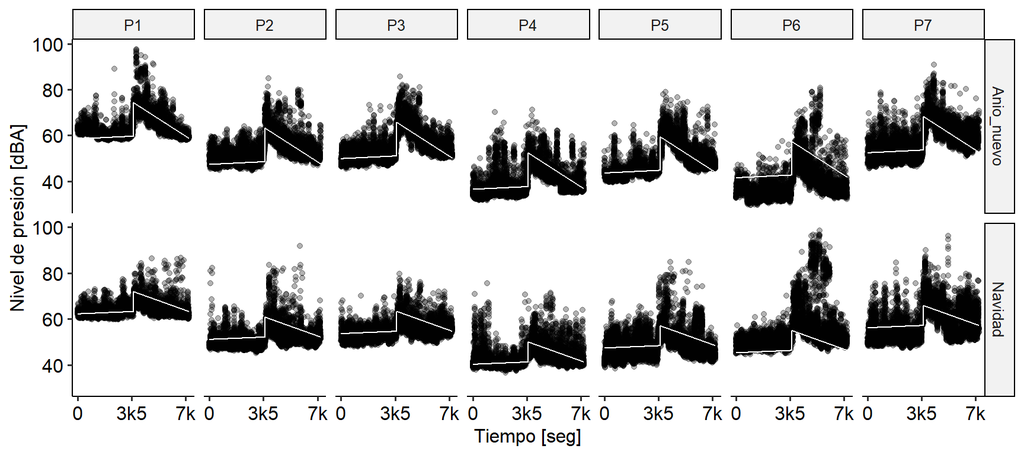

```r
data_m1.lm <- tabla.datos %>% mutate(pred = predict(pirotecnia.lme), res = resid(pirotecnia.lme))

figura2 = ggplot(tabla.datos, aes(x=tiempo, y=nivel_sonoro))+
  geom_point(alpha = 0.3)+
  facet_grid(fecha~punto)+
  theme_pubr(base_size = 12, margin = TRUE)+
  scale_x_continuous(name= "Tiempo [seg]", breaks=c(0,3500,7000), labels=c("0","3k5","7k")) +
  labs(y = "Nivel de presión [dBA]") +
  theme(legend.position = "top",
        legend.title = element_blank())+
  geom_line(data=data_m1.lm, aes(x=tiempo, y=pred, group=punto), color='white')

figura2
```